# Istraživanje veze izmedu osobnosti i fizičkih karakteristika

Matija Jakovac 0036538710, Mirna Knez 0036539653, Marin Kvesić 0036541216, Nikola Marić 0036542031

2024-01-21

### Učitavanje i djelomični prikaz korištenih podataka

```r
data <- read.csv("MBTI.csv")
head(data,3)
```

```
##   X S.No AGE HEIGHT WEIGHT    SEX ACTIVITY.LEVEL PAIN.1 PAIN.2 PAIN.3 PAIN.4
## 1 0    1  53     62    125 Female            Low      0      0      0      0
## 2 1    2  52     69    157   Male           High      7      8      5      3
## 3 2    3  30     69    200   Male           High      0      0      0      0
##   MBTI          E          I           S          N          T          F
## 1 ESFJ  0.9084579 -1.0968036 -0.06968492 -0.6744897 -0.3186394  0.1046335
## 2 ISTJ -0.6045853  0.4727891 -0.28221615 -0.4307273  1.1503494 -1.1503494
## 3 ESTJ  0.4727891 -0.6045853 -0.13971030 -0.5894558  0.3186394 -0.3186394
##            J          P POSTURE
## 1 0.78103381 -0.9388143       A
## 2 0.16421078 -0.2759211       B
## 3 0.05451892 -0.1642108       A
```

### Učitavanje potrebnih paketa za obradu podataka

```r
library(ggplot2)
library(dplyr)
library(lmtest)
library(cowplot)
library(gridExtra)
```

## Zadatak 1: Postoji li veza izmedu tipa licnosti i nacina drzanja?

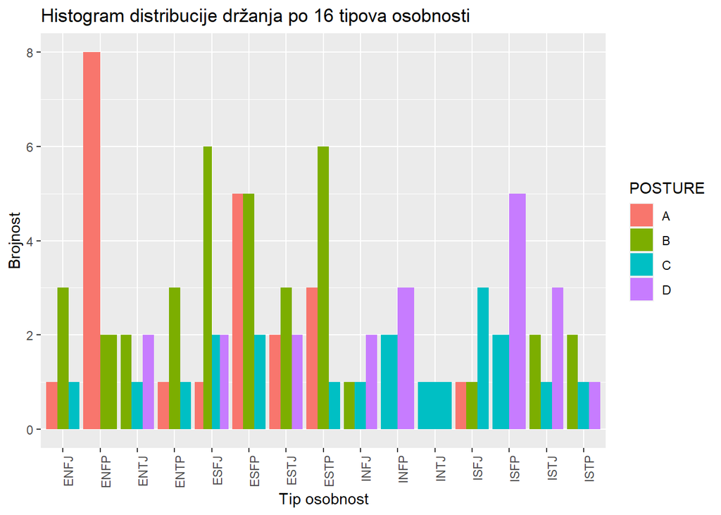

```r
# Kreiranje histograma za svaku osobnost i drzanje
ggplot(data, aes(x = MBTI, fill = POSTURE)) +
  geom_bar(position = position_dodge()) +
  xlab("Tip osobnost") +
  ylab("Brojnost") +
  ggtitle("Histogram distribucije držanja po 16 tipova osobnosti") +
  theme(axis.text.x = element_text(angle = 90, hjust = 1))
```

#### Za rješavanje ćemo koristit Chi-kvadrat test nezavisnosti

#### H0: Nema zavisnosti izmedu tipa licnosti i nacina drzanja

#### H1: Postoji zavisnost izmedu tipa licnosti i nacina drzanja

##### Kontigencijska tablica držanja i tipa osobnosti

```r
contingency_table <- table(data$MBTI, data$POSTURE)
print(contingency_table)
```

```
##
##        A B C D
##   ENFJ 1 3 1 0
##   ENFP 8 2 0 0
##   ENTJ 0 2 1 2
##   ENTP 1 3 1 0
##   ESFJ 1 6 2 2
##   ESFP 5 5 2 0
##   ESTJ 2 3 0 2
##   ESTP 3 6 1 0
##   INFJ 0 1 1 2
##   INFP 0 0 2 3
##   INTJ 0 0 1 0
##   ISFJ 1 1 3 0
##   ISFP 0 0 2 5
##   ISTJ 0 2 1 3
##   ISTP 0 2 1 1
```

```r
# Izvodenje Chi-kvadrat testa
chi_test_result <- chisq.test(contingency_table)
```

##### Prikazanom kontigencijskom tablicom i upozorenjem R-a pri izvođenju Chi-kvadrat zaključujemo da će osobnosti morati podijeliti u skupine veće brojnosti kako bi dobili značajne rezultate jer se ne zadovoljava pretpostavka da su očekivane vrijednosti veće od 5.

```r
# Stvaranje novih stupaca koji označuju personiliziranu vrijednost za svaki par osobnosti
data$EI <- substr(data$MBTI, 1, 1)
data$SN <- substr(data$MBTI, 2, 2)
data$TF <- substr(data$MBTI, 3, 3)
data$JP <- substr(data$MBTI, 4, 4)
```

#### Prikaz pojedinačnih histograma držanja po komplementarnim parovima osobnosti koristeći prije iskorištenu funkciju za crtanje histograma

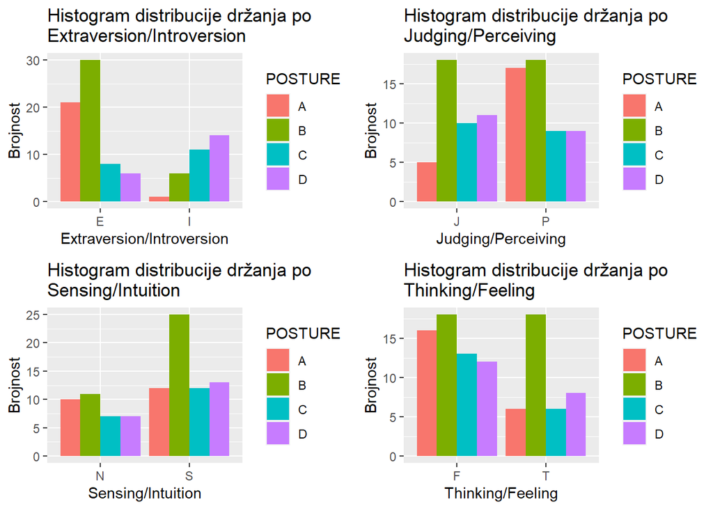

#### Kontigencijske tablice držanja po komplementarnim parovima osobnosti

```r
# Stvaranje kontigencijskih tablica za parove osobnosti i nacin drzanja
contingency_table_EI <- table(data$EI, data$POSTURE)
contingency_table_SN <- table(data$SN, data$POSTURE)
contingency_table_TF <- table(data$TF, data$POSTURE)
contingency_table_JP <- table(data$JP, data$POSTURE)
```

```
##
##      A  B  C  D
##   E 21 30  8  6
##   I  1  6 11 14
```

```
##
##      A  B  C  D
##   N 10 11  7  7
##   S 12 25 12 13
```

```
##
##      A  B  C  D
##   F 16 18 13 12
##   T  6 18  6  8
```

```
##
##      A  B  C  D
##   J  5 18 10 11
##   P 17 18  9  9
```

#### Prikazanim tablicama zaključujemo da je moguće izvršiti Chi-kvadrat test nezavisnosti pošto je zadovoljena pretpostavka da su vrijednosti očekivane frekvencije veće od 5.

##### Chi-kvadrat test za E/I

```r
chi_test_result_EI <- chisq.test(contingency_table_EI)
print(chi_test_result_EI)
```

```
##
##  Pearson's Chi-squared test
##
## data:  contingency_table_EI
## X-squared = 30.114, df = 3, p-value = 1.306e-06
```

##### Chi-kvadrat test za S/N

```r
chi_test_result_SN <- chisq.test(contingency_table_SN)
print(chi_test_result_SN)
```

```
##
##  Pearson's Chi-squared test
##
## data:  contingency_table_SN
## X-squared = 1.3296, df = 3, p-value = 0.7221
```

##### Chi-kvadrat test za T/F

```r
chi_test_result_TF <- chisq.test(contingency_table_TF)
print(chi_test_result_TF)
```

```
##
##  Pearson's Chi-squared test
##
## data:  contingency_table_TF
## X-squared = 3.5441, df = 3, p-value = 0.3151
```

##### Chi-kvadrat test za J/P

```r
chi_test_result_JP <- chisq.test(contingency_table_JP)
print(chi_test_result_JP)
```

```
##
##  Pearson's Chi-squared test
##
## data:  contingency_table_JP
## X-squared = 6.0148, df = 3, p-value = 0.1109
```

#### Koristeći nivo značajnosti alfa=0.05 te uspoređujući pojedinačnu p-vrijednost uočavamo da je za par Extroversion/Introversion postoji zavisnost s načinom držanja. Također se osobnosti može podijeliti u 4 preddefinirane MBTI grupe te s njima izvesti isti test nezavisnosti.

##### Definiranje grupa prema MBTI kodovima

```r
# Definiranje 4 MBTI grupe po 16personalities.com
data$Group <- ifelse(data$MBTI %in% c("INTJ", "INTP", "ENTJ", "ENTP"), "Analysts",
              ifelse(data$MBTI %in% c("INFJ", "INFP", "ENFJ", "ENFP"), "Diplomats",
              ifelse(data$MBTI %in% c("ISTJ", "ISFJ", "ESTJ", "ESFJ"), "Sentinels",
              ifelse(data$MBTI %in% c("ISTP", "ISFP", "ESTP", "ESFP"), "Explorers", NA))))
```

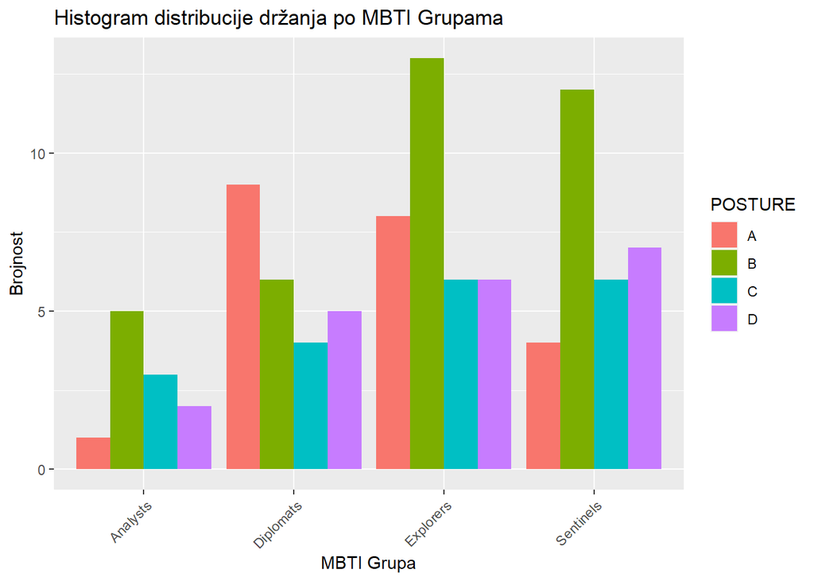

##### Prikaz kontigencijske tablice za 4 MBTI grupe

```
##
##              A  B  C  D
##   Analysts   1  5  3  2
##   Diplomats  9  6  4  5
##   Explorers  8 13  6  6
##   Sentinels  4 12  6  7
```

```r
# Izvođenje Chi-kvadrat testa za grupe
chi_test_result_Group <- chisq.test(contingency_table_Group)
print(chi_test_result_Group)
```

```
##
##  Pearson's Chi-squared test
##
## data:  contingency_table_Group
## X-squared = 6.3976, df = 9, p-value = 0.6996
```

##### Koristeći 4 MBTI grupe uočavamo isto upozorenje kao i kod korištenja svih 16 osobnosti, ali ako i zanemarimo taj problem p-vrijednost je prevelika da se odbaci H0.

### Zaključak za zad. 1: Postoji zavisnost između načina držanja i para osobnosti Extroversion/Introversion i za taj test odbacujemo H0 u korist H1.

## Zadatak 2: Jesu li fizicki aktivniji ljudi takoder i ekstrovertiraniji?

#### Ovaj zadatak ćemo riješiti koristeći ANOVA-u te zbog toga moramo kategorijsku varijablu razine fizičke aktivnosti pretvoriti u faktor.

```r
data$ACTIVITY.LEVEL <- as.factor(data$ACTIVITY.LEVEL)
activity_means <- aggregate(E ~ ACTIVITY.LEVEL, data = data, mean)
```

#### H0: Srednje vrijednosti ekstrovertiranosti su jednake za sve skupine.

#### H1: Srednje vrijednosti ekstrovertiranosti nisu jednake za sve skupine.

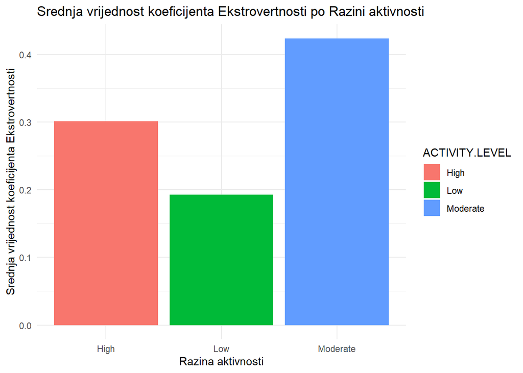

#### Provjera pretpostavki ANOVA-e odnosno normalne distrubiranosti populacija te jednakosti njihovih varijanci

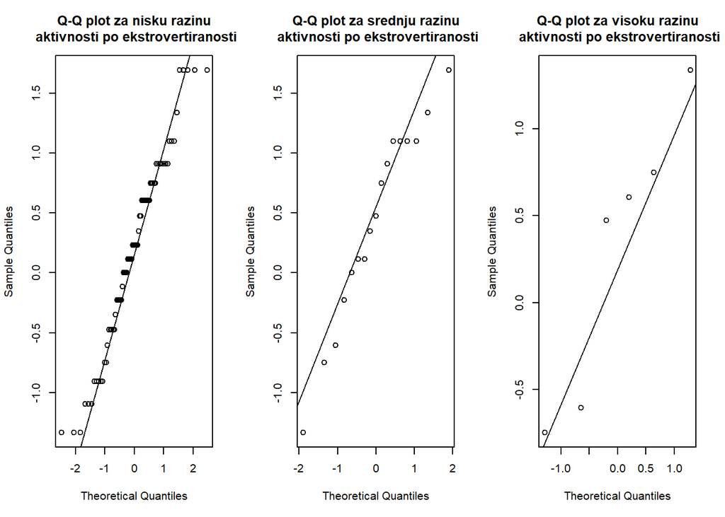

```r
data_low <- subset(data, ACTIVITY.LEVEL == "Low")
data_moderate <- subset(data, ACTIVITY.LEVEL == "Moderate")
data_high <- subset(data, ACTIVITY.LEVEL == "High")

par(mfrow = c(1, 3))

qqnorm(data_low$E, main = "")
qqline(data_low$E)
title(main = "Q-Q plot za nisku razinu\n aktivnosti po ekstrovertiranosti")

qqnorm(data_moderate$E, main = "")
qqline(data_moderate$E)
title(main = "Q-Q plot za srednju razinu\n aktivnosti po ekstrovertiranosti")

qqnorm(data_high$E, main = "")
qqline(data_high$E)
title(main = "Q-Q plot za visoku razinu\n aktivnosti po ekstrovertiranosti")
```

```r
print(paste("Varijanca ekstrovertiranosti za nisku razinu aktivnosti:", var(data_low$E)))
```

```
## [1] "Varijanca ekstrovertiranosti za nisku razinu aktivnosti: 0.634190516204884"
```

```r
print(paste("Varijanca ekstrovertiranosti za srednju razinu aktivnosti:", var(data_moderate$E)))
```

```
## [1] "Varijanca ekstrovertiranosti za srednju razinu aktivnosti: 0.682382173696437"
```

```r
print(paste("Varijanca ekstrovertiranosti za visoku razinu aktivnosti:", var(data_high$E)))
```

```
## [1] "Varijanca ekstrovertiranosti za visoku razinu aktivnosti: 0.662214057320342"
```

#### Iz prikazanih q-q plotova i ispisa varijanci zaključujemo da su uvjeti za izvođenje ANOVA-e zadovoljeni.

```r
# Izvođenje ANOVA
anova_result <- aov(E ~ ACTIVITY.LEVEL, data = data)
anova_summary <- summary(anova_result)
print(anova_summary)
```

```
##                Df Sum Sq Mean Sq F value Pr(>F)
## ACTIVITY.LEVEL  2   0.76  0.3811   0.592  0.555
## Residuals      94  60.53  0.6439
```

#### Zaključak za zad. 2: S obzirom na veliku p-vrijednost zaključujemo da fizički aktivniji ljudi nisu nužno i ekstrovertiraniji te ne možemo odbaciti H0.

## Zadatak 3: Postoji li razlika u visini/tezini ljudi s obzirom na tip licnosti?

#### Ovaj zadatak ćemo riješiti koristeći t-testove za svaki komplementarni par osobnosti i tezinu i ANOVA-u za 4 MBTI grupe i visinu.

#### H0: Srednje vrijednosti tezine su jednake za par osobnosti.

#### H1: Srednje vrijednosti tezine nisu jednake za par osobnosti.

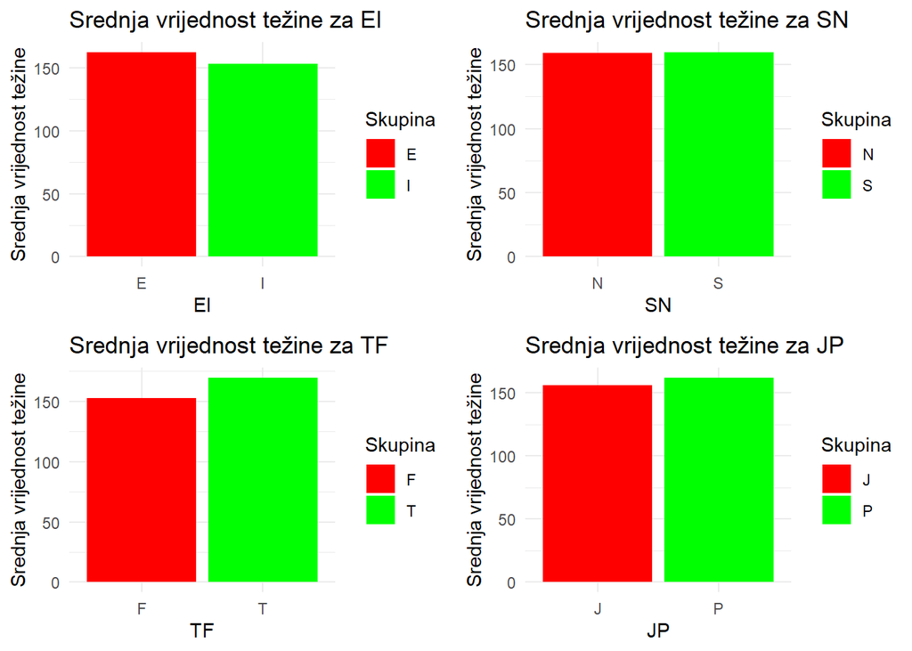

#### Provjera normalnosti podataka težine unutar komplementarnih parova osobnosti

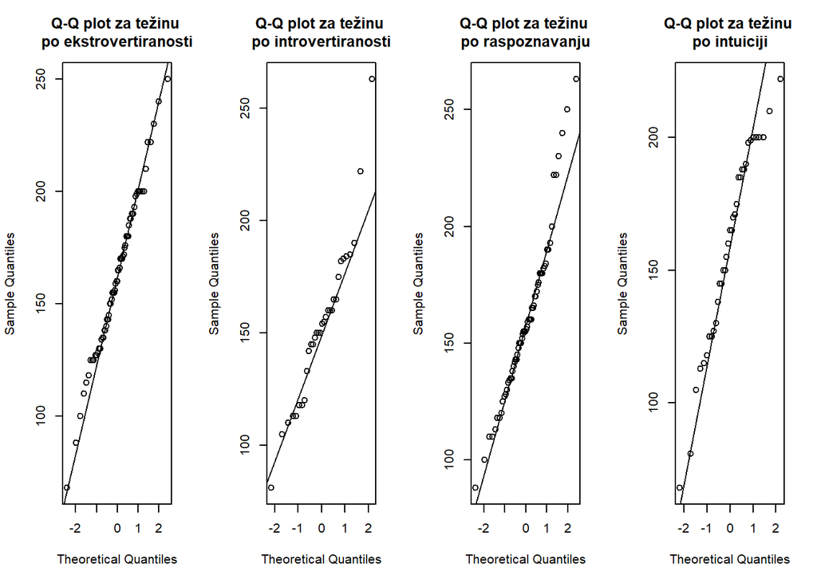

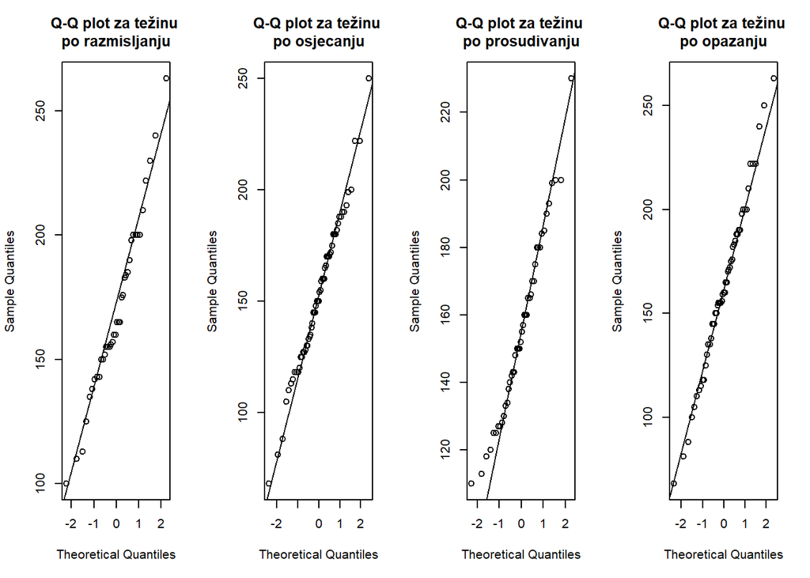

#### Prikazani q-q plotovi ukazuju na normalnu razdiobu težine u parovima osobnosti

#### Izvršavanje t-testova za težinu za svaki par osobnosti - t-test za dva uzorka s nepoznatim i nejednakim varijancama

```r
for(skupina in c("EI", "SN", "TF", "JP")) {
  # Izvršavanje testa
  t_test_weight <- t.test(WEIGHT ~ data[[skupina]], data = data)

  cat("=====================================\n")
  cat("Rezultati za par osobnosti: ", skupina, "\n")

  print(t_test_weight)

  # Zaključak za težinu
  if (t_test_weight$p.value < 0.05) {
    print("Odbacujemo H0 i ima značajne razlike u težini za ovu skupinu")
  } else {
    print("Ne odbacujemo H0 i nema značajne razlike u težini za ovu skupinu")
  }

}
```

```
## =====================================
## Rezultati za par osobnosti:  EI
##
##  Welch Two Sample t-test
##
## data:  WEIGHT by data[[skupina]]
## t = 1.2069, df = 62.564, p-value = 0.232
## alternative hypothesis: true difference in means between group E and group I is not equal to 0
## 95 percent confidence interval:
##  -6.144958 24.878612
## sample estimates:
## mean in group E mean in group I
##        162.5231        153.1562
##
## [1] "Ne odbacujemo H0 i nema značajne razlike u težini za ovu skupinu"
## =====================================
## Rezultati za par osobnosti:  SN
##
##  Welch Two Sample t-test
##
## data:  WEIGHT by data[[skupina]]
## t = -0.1091, df = 66.546, p-value = 0.9135
## alternative hypothesis: true difference in means between group N and group S is not equal to 0
## 95 percent confidence interval:
##  -16.52276  14.81031
## sample estimates:
## mean in group N mean in group S
##        158.8857        159.7419
##
## [1] "Ne odbacujemo H0 i nema značajne razlike u težini za ovu skupinu"
## =====================================
## Rezultati za par osobnosti:  TF
##
##  Welch Two Sample t-test
##
## data:  WEIGHT by data[[skupina]]
## t = -2.2893, df = 77.875, p-value = 0.02477
## alternative hypothesis: true difference in means between group F and group T is not equal to 0
## 95 percent confidence interval:
##  -31.672419  -2.208045
## sample estimates:
## mean in group F mean in group T
##        152.7966        169.7368
##
## [1] "Odbacujemo H0 i ima značajne razlike u težini za ovu skupinu"
## =====================================
## Rezultati za par osobnosti:  JP
##
##  Welch Two Sample t-test
##
## data:  WEIGHT by data[[skupina]]
## t = -0.8477, df = 90.072, p-value = 0.3989
## alternative hypothesis: true difference in means between group J and group P is not equal to 0
## 95 percent confidence interval:
##  -20.173350   8.106454
## sample estimates:
## mean in group J mean in group P
##        156.1364        162.1698
##
## [1] "Ne odbacujemo H0 i nema značajne razlike u težini za ovu skupinu"
```

#### Jedini par u kojoj je p-vrijednost bila manja od nivoa značajnosti jer bio par Thinking/Feeling tako da zaključujemo da postoji razlika u težini s tim parom osobnosti.

#### U nastavku je prikazano provođenje ANOVA-e uz prvotno koristenje deskriptivne statistke za prikaz podataka te ispitivanje pretpostavki kao i u prijašnjoj slučaju.

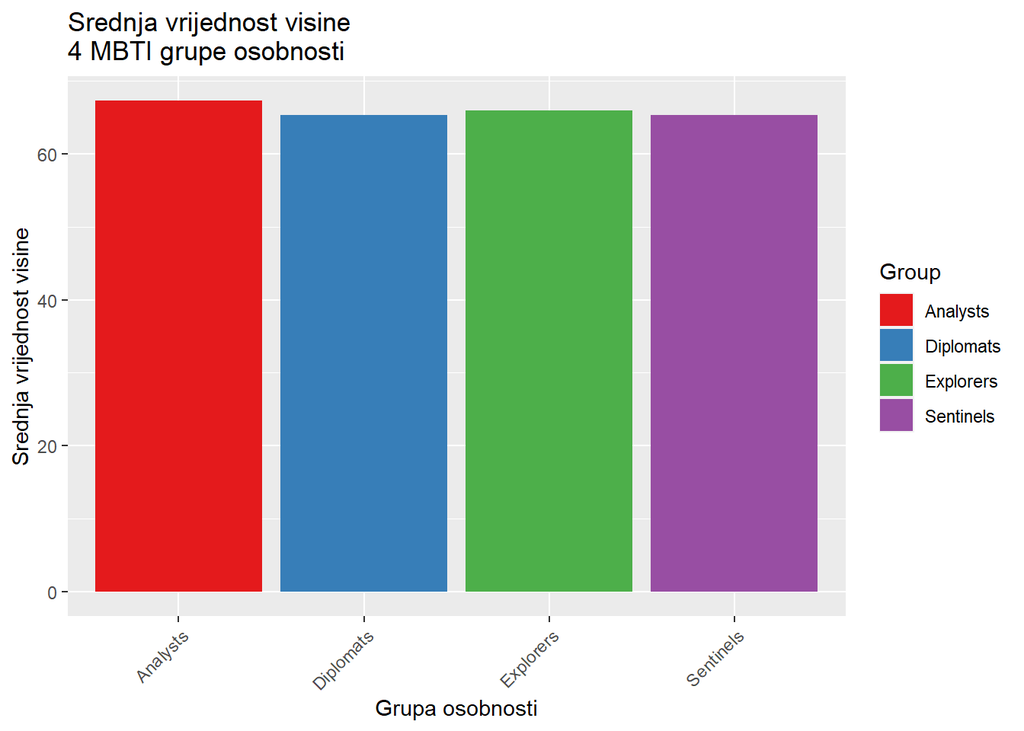

#### Ispitivanje normalne razdiobe visine u 4 MBTI grupe

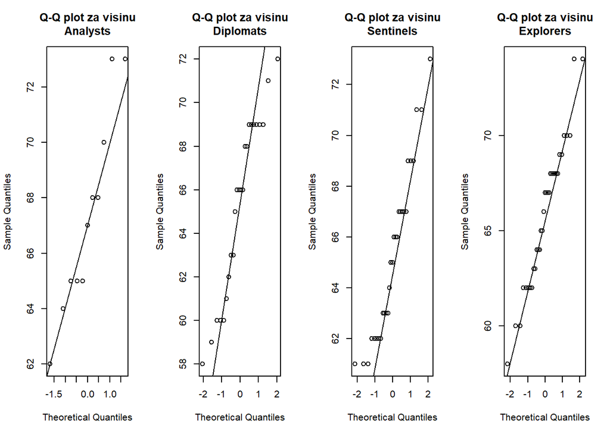

#### Podatci o visinu su normalno distribuirani u 4 MBTI grupe

#### Ispitivanje jednakosti varijance za 4 MBTI grupe

```
## [1] "Varijanca visine za Analysts: 12.8181818181818"
```

```
## [1] "Varijanca visine za Diplomats: 17.1014492753623"
```

```
## [1] "Varijanca visine za Sentinels: 11.2216748768473"
```

```
## [1] "Varijanca visine za Explorers: 14.6723484848485"
```

#### Uočavamo da pretpostavka da su varijance iste u svim populacijama nije zadovoljena no svejedno ćemo provesti ANOVA-u iako onda njen rezultat ne trebamo shvaćati najozbiljnije.

```
## [1] "ANOVA test za visinu za sve grupe"
```

```
##             Df Sum Sq Mean Sq F value Pr(>F)
## Group        3   35.8   11.93    0.85   0.47
## Residuals   93 1305.2   14.04
```

#### Velika p-vrijednost od 0.47 uzakuje na to da nema značajne razlike u srednjim vrijednostima visine u 4 MBTI grupe.

#### Zaključak za zad. 3: Provedeći t-test za težinu uz parove osobnosti te ANOVA-u za visinu za 4 MBTI grupe jedino dolazimo do zaključka da postoji značajna razlika u srednjim vrijednostima težine u paru osobnosti Thinking/Feeling i za taj t-test odbacujemo H0 u korist H1.

## Zadatak 4: Mozete li pomocu danih znacajki naslutiti tip licnosti ili rezultat na pojedinoj karakteristici?

### Izgradnja modela za predviđanje

#### Za svaku od karakteristika ličnosti (E/I, S/N, T/F, J/P) izgrađeni su modeli linearnih regresija koristeći različite značajke iz naših podataka. Modeli se grade s ciljem da predvidimo pojedinu karakteristiku ličnosti na temelju drugih dostupnih informacija kao što su držanje, razina boli, spol, starost, visina i težina.

### Izgradnja modela za E/I

#### Modeli za predviđanje Extraversion/Introversion:

#### Model držanja (model_E_Posture): Ovaj model istražuje kako držanje utječe na vjerojatnost da je osoba ekstrovertirana.

#### Model razine boli 1 (model_E_Pain1): Ovaj model proučava odnos između intenziteta boli u vratu koju osoba doživljava i njezine ekstrovertiranosti.

#### Kombinirani model držanja i razine boli 1 (model_E_Pain1_Posture): Kombinira držanje i razinu boli u vratu da bi pružio sveobuhvatniji uvid u njihov zajednički utjecaj na ekstrovertiranost osobe.

#### Kombinirani model za introverziju (model_I_Pain1_Posture): Slično kao prethodni, ali s fokusom na predviđanje introvertiranosti, analizira kombinirani efekt držanja i razine boli u vratu na introvertiranost.

```r
model_E_Posture <- lm(E ~ POSTURE, data = data)
model_E_Posture_summary <- summary(model_E_Posture)
r_squared_E_Posture <- model_E_Posture_summary$r.squared
p_value_E_Posture <- coef(model_E_Posture_summary)[, "Pr(>|t|)"]
tested_variables_E_Posture <- names(coef(model_E_Posture_summary))

# homoscedastičnost - uvjet gdje varijanca ostaje konstanta za sve vrijednosti varijable.
# heteroscedastičnost - stanje gdje varijanca nije konstantna, već se mijenja s veličinom opažanja
residuals_E_Posture <- residuals(model_E_Posture)
fitted_E_Posture <- fitted(model_E_Posture)

model_E_Pain1 <- lm(E ~ PAIN.1, data = data)
summary_E_Pain1 <- summary(model_E_Pain1)

model_E_Pain1_Posture <- lm(E ~ PAIN.1 + POSTURE, data = data)
model_I_Pain1_Posture <- lm(I ~ PAIN.1 + POSTURE, data = data)
```

```
##                       Model  R_Squared F_p_value Expectancy_Residuals
## value           E ~ POSTURE 0.24542290 10.082614         1.805029e-17
## value1           E ~ PAIN.1 0.03726019  3.676713         3.711087e-18
## value2 E ~ PAIN.1 + POSTURE 0.28667218  9.243240         2.119112e-17
## value3 I ~ PAIN.1 + POSTURE 0.28805419  9.305830         9.724288e-20
##        MAX_var_Residuals MIN_var_Residuals
## value          0.5395791         0.4542624
## value1         0.8204496         0.5561723
## value2         0.4932052         0.4342048
## value3         0.6464388         0.4716965
```

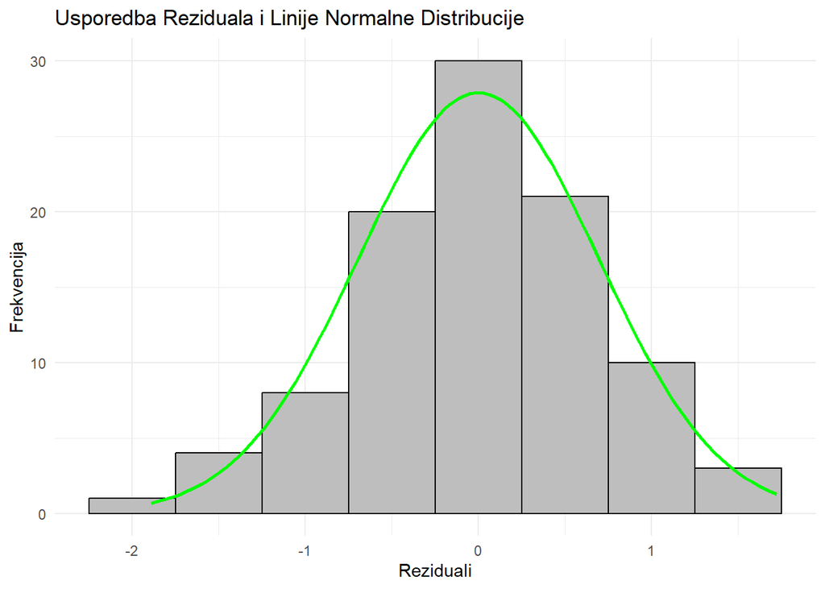

#### Zaključak za Graf 1: Histogram reziduala modela ‘E ~ POSTURE’ pokazuje da reziduali prate normalnu distribuciju, što ukazuje na to da je model dobro prilagođen podacima. To znači da su pretpostavke o normalnosti reziduala za ovaj model uglavnom zadovoljene.

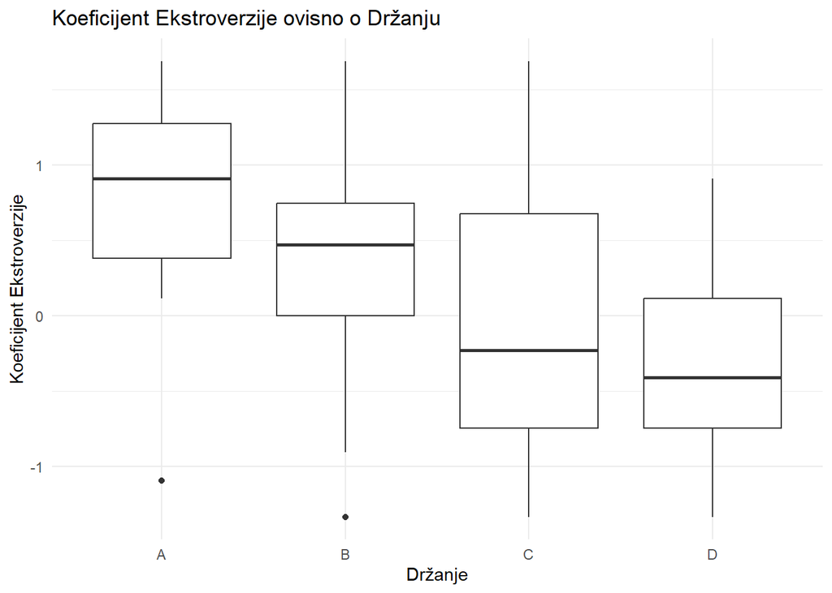

#### Zaključak za Graf 2: Boxplot pokazuje varijacije koeficijenta ekstrovertiranosti u odnosu na različite tipove držanja. Primjećuje se trend u kojem osobe s ispravnijim držanjem imaju veće koeficijente ekstrovertiranosti. To implicira da bi držanje moglo biti povezano s ekstrovertiranim ponašanjem.

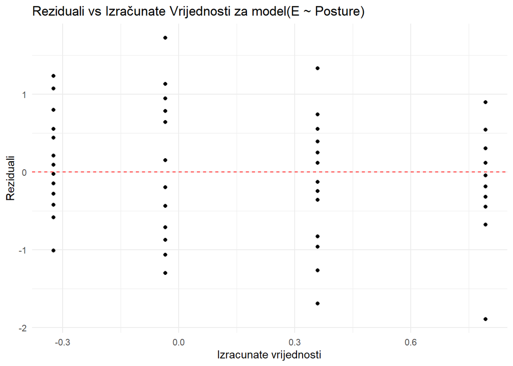

#### Zaključak za Graf 3: Graf reziduala u odnosu na izračunate vrijednosti ne pokazuje očite uzorke, što upućuje na to da je varijabilnost reziduala konzistentna preko svih razina predviđenih vrijednosti. Ovo podržava pretpostavke o homoscedastičnosti i linearnosti modela.

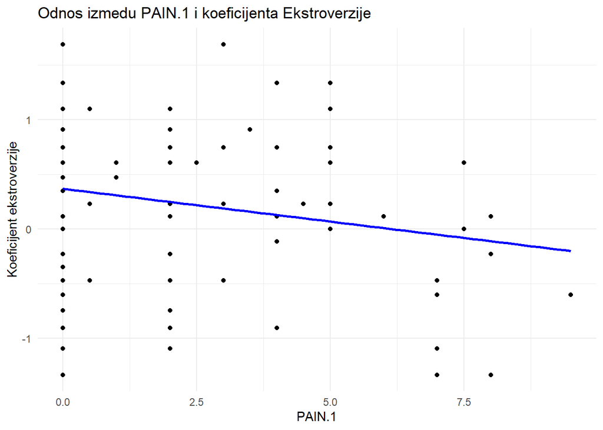

#### Zaključak za Graf 4: Trend linija ukazuje na negativnu korelaciju između intenziteta boli u vratu (PAIN.1) i koeficijenta ekstroverzije. To sugerira da veći stupanj boli može biti povezan s nižim nivoima ekstrovertnosti.

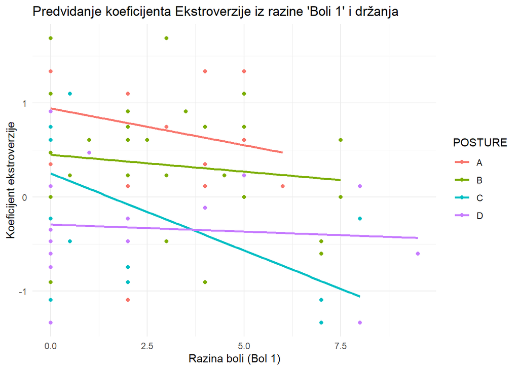

### Izgradnja modela za S/N

```r
model_S_Age <- lm(S ~ AGE, data = data)
model_S_Sex <- lm(S ~ SEX, data = data)
model_S_Height <- lm(S ~ HEIGHT, data = data)

# Dijeljenje u grupe
data$age_group <- cut(data$AGE,
                      breaks=quantile(data$AGE, probs=0:4/4),
                      include.lowest=TRUE,
                      labels=c("Q1", "Q2", "Q3", "Q4"))

# Srednja vrijednost S za svaku dobnu skupinu
age_group_means <- data %>%
  group_by(age_group) %>%
  summarize(mean_S = mean(S, na.rm = TRUE))

# FACTOR za spol i dobnu skupinu
data$sex_age_group <- interaction(data$SEX, data$age_group)


# Ispis testa
model_S_SexHeightAge <- lm(S ~ SEX + HEIGHT + AGE, data = data)
model_N_SexHeightAge <- lm(N ~ SEX + HEIGHT + AGE, data = data)

# Srednja vrijednost S za svaku grupu visine/dobne skupine
age_height_means <- data %>%
  group_by(AGE, HEIGHT) %>%
  summarize(mean_S = mean(S, na.rm = TRUE), .groups = 'drop')
```

```
##                         Model  R_Squared F_p_value Expectancy_Residuals
## value                 S ~ AGE 0.03547746  3.494329        -1.020491e-18
## value1                S ~ SEX 0.04641115  4.623648        -1.037704e-17
## value2             S ~ HEIGHT 0.03268610  3.210105        -1.790470e-17
## value3 S ~ SEX + HEIGHT + AGE 0.09024062  3.074944         9.409925e-18
## value4 N ~ SEX + HEIGHT + AGE 0.09511710  3.258576         1.179545e-17
##        MAX_var_Residuals MIN_var_Residuals
## value          0.1669328        0.09690901
## value1         0.1863025        0.09443405
## value2         0.1832654        0.09794126
## value3         0.1665273        0.08992870
## value4         0.2024745        0.06499835
```

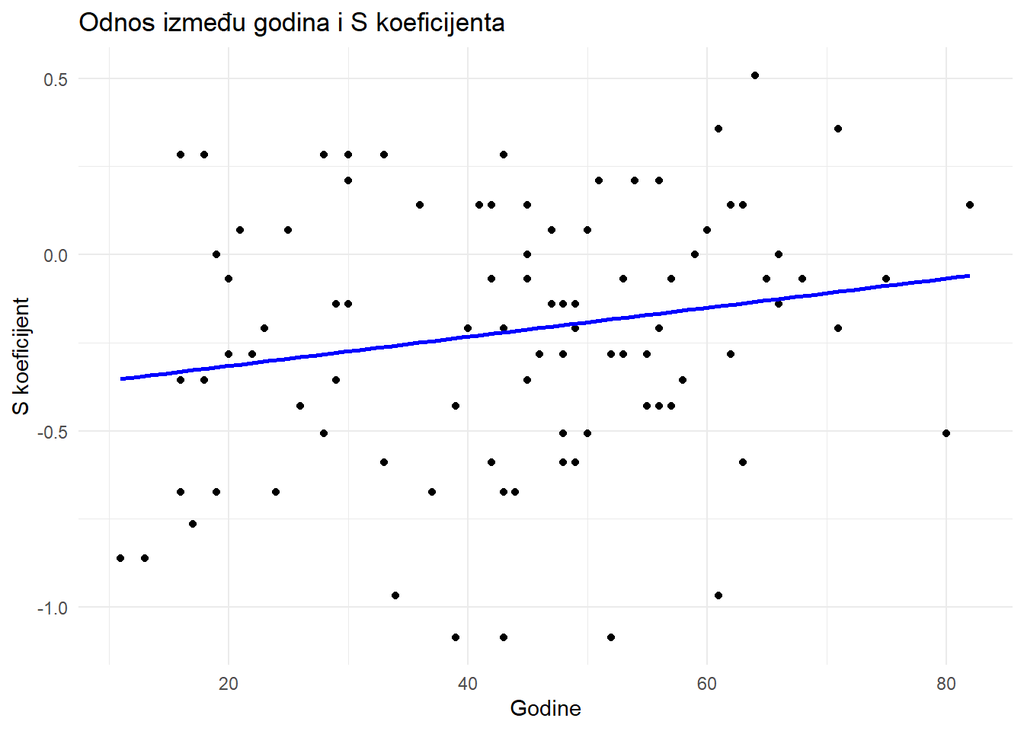

#### Zaključak za Graf 6: Model pokazuje da s godinama raste S koeficijent, što može ukazivati na to da starije osobe razvijaju jaču sklonost prema raspoznavanju informacija.

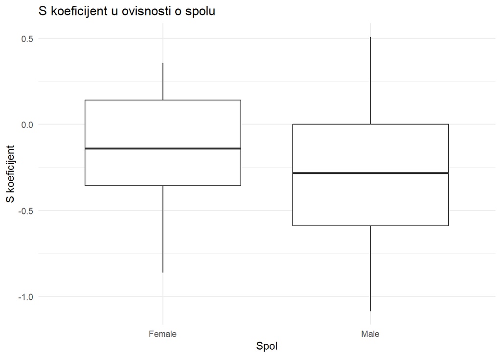

#### Zaključak za Graf 7: Postoje značajne razlike u S koeficijentu između spolova. Ovo upućuje na to da bi spol mogao imati utjecaja na raspoznavalačku/intuitivnu dimenziju ličnosti.

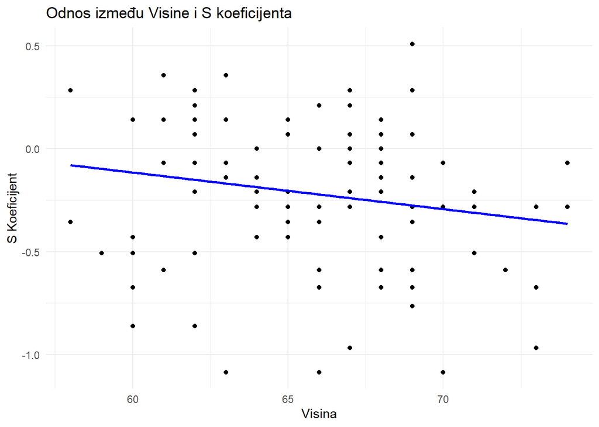

#### Zaključak za Graf 8: Postoji naznaka da viši ljudi imaju tendenciju prema nižem S koeficijentu, što sugerira da bi visina mogla imati ulogu u razvoju raspoznavalačkih/intuitivnih preferencija.

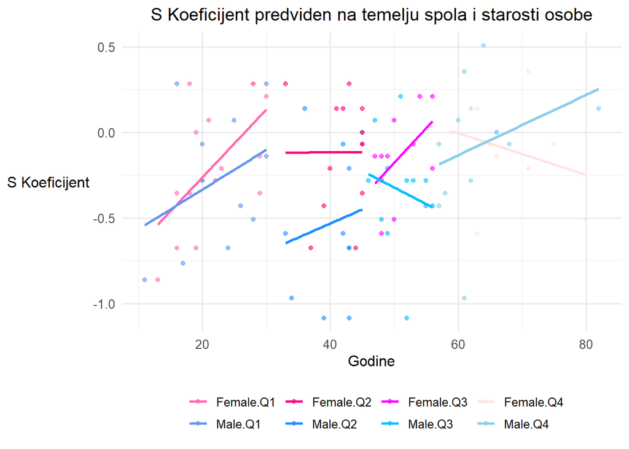

#### Zaključak za Graf 9: Dobne skupine pokazuju različite trendove u S koeficijentu, što implicira važnost uzimanja u obzir dobi i spola zajedno pri analizi raspoznavalačkih preferencija.

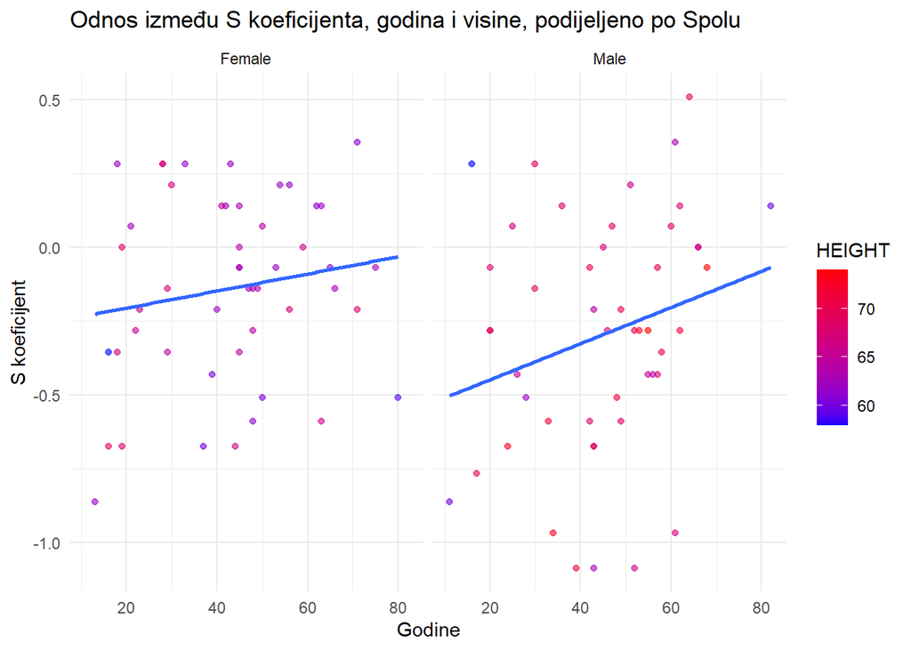

### Izgradnja modela za T/F

#### Modeli za predviđanje Thinking/Feeling:

#### Model spola (model_T_Sex): Ovaj model istražuje kako spol utječe na tendenciju osobe prema razmišljanju/osjećanju, pružajući uvid u to kako rodne razlike mogu utjecati na ove dijelove ličnosti.

#### Model visine (model_T_Height): Analizira se povezanost između visine osobe i sklonosti razmišljanju, sugerirajući kako fizičke karakteristike mogu biti povezane s kognitivnim stilom.

#### Model težine (model_T_Weight): Ovaj model ocjenjuje da li i kako tjelesna masa utječe na razmišljanje, istražujući povezanost između fizičkih mjera i psiholoških preferencija.

#### Kombinirani model spola, visine i težine (model_T_SexHeightWeight): Kombinira spol, visinu i težinu u jedinstvenom modelu kako bi se procijenio njihov zajednički utjecaj na razmišljanje, dajući sveobuhvatniji pregled kako ove varijable međudjeluju u formiranju kognitivnog stila.

#### Kombinirani model za osjećanje (model_F_SexHeightWeight): Sličan prethodnom, ali usmjeren na predviđanje osjećanja, ovaj model također uzima u obzir spol, visinu i težinu, pružajući balansiran pogled na oba dijela ličnosti.

```r
model_T_Sex <- lm(T ~ SEX, data = data)
model_T_Height <- lm(T ~ HEIGHT, data = data)
model_T_Weight <- lm(T ~ WEIGHT, data = data)
model_T_SexHeightWeight <- lm(T ~ SEX + HEIGHT + WEIGHT, data = data)
model_F_SexHeightWeight <- lm(F ~ SEX + HEIGHT + WEIGHT, data = data)
```

[output not shown]

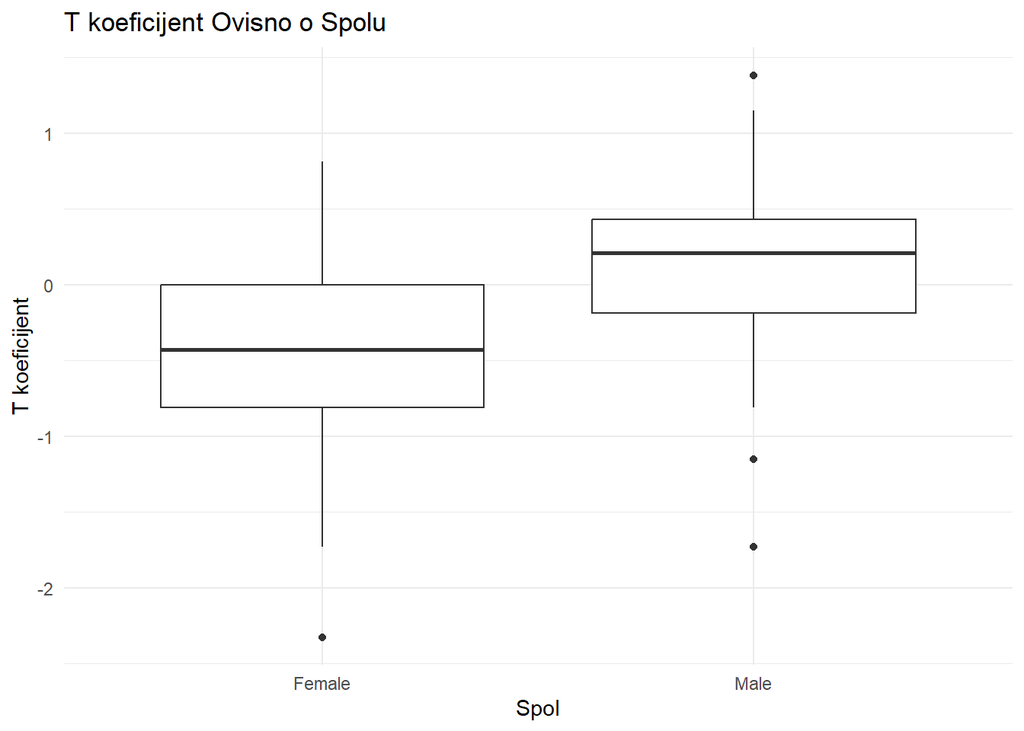

#### Zaključak za Graf 11: Boxplot pokazuje da muškarci imaju više vrijednosti T koeficijenta u usporedbi sa ženama, što može ukazivati na spolne razlike u pristupu razmišljanju.

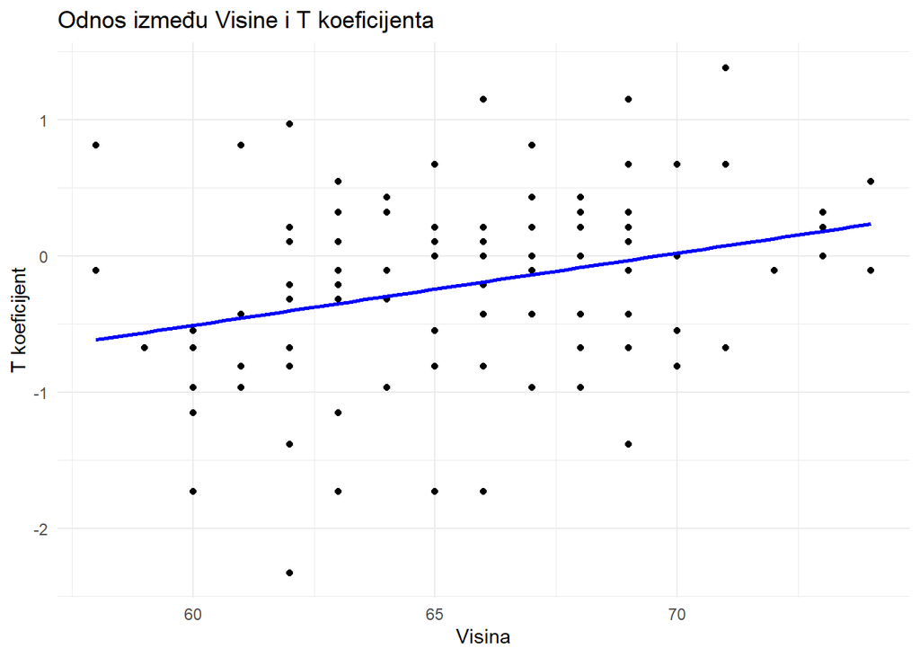

#### Zaključak za Graf 12: Postoji pozitivna korelacija između visine i T koeficijenta, što sugerira da visina može biti faktor u razvoju razmišljanja prema logici i analitičkom pristupu.

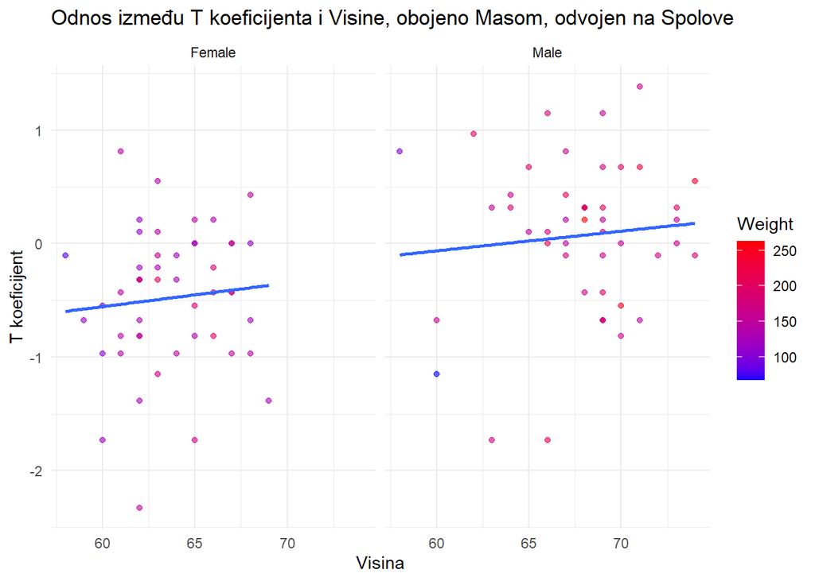

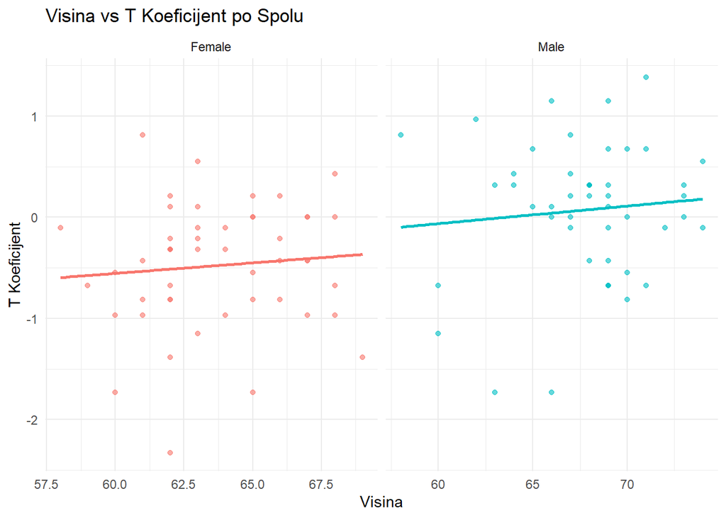

#### Zaključak za Graf 14: Rešetkasti graf ovisno o spolu pokazuje da je utjecaj visine na T koeficijent sličan kod oba spola, implicirajući da bi visina mogla biti nezavisni prediktor razmišljanja.

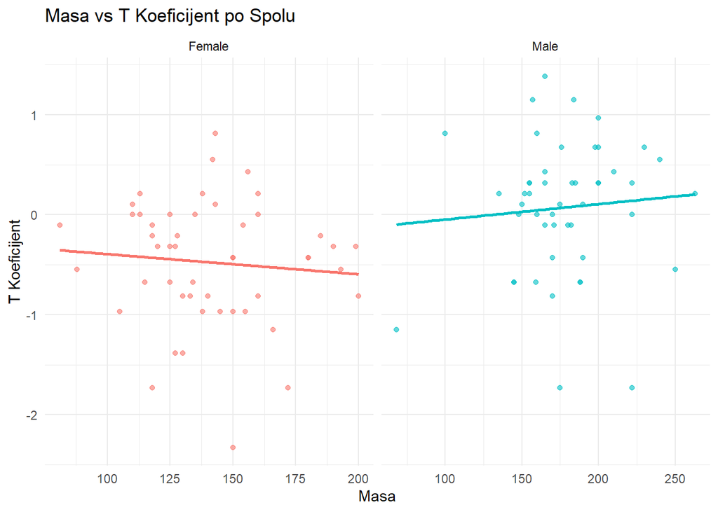

#### Zaključak za Graf 15: Graf pokazuje da masa utječe na T koeficijent, s različitim učincima ovisno o spolu, što ukazuje na kompleksnost odnosa između fizičkih karakteristika i kognitivnog stila.

### Izgradnja modela za J/P

#### Modeli za predviđanje Judging/Perceiving dijela ličnosti:

#### Model spola (model_J_Sex): Ovaj model istražuje kako spol utječe na tendenciju osobe prema prosudivackom (Judging - J) ili percepcijskom (Perceiving - P) dijelu ličnosti, pružajući uvid u to kako rodne razlike mogu utjecati na ove dijelove ličnosti.

#### Model boli 3 (model_J_Pain3): Analizira se povezanost između intenziteta boli u leđima i sklonosti prosudivackom dijelu, sugerirajući kako fizičko stanje i doživljaj boli mogu biti povezani s kognitivnim stilom.

#### Kombinirani model držanja i boli 3 (model_J_Posture_Pain3): Ovaj model kombinira informacije o držanju i intenzitetu boli u leđima kako bi se procijenio njihov zajednički utjecaj na prosudivacki dio ličnosti, dajući sveobuhvatniji pregled kako ove varijable međudjeluju u formiranju kognitivnog stila.

#### Kombinirani model za percepciju (model_P_Posture_Pain3): Sličan prethodnom, ali usmjeren na predviđanje percepcijske strane ličnosti, ovaj model također uzima u obzir držanje i intenzitet boli u leđima, pružajući balansiran pogled na oba dijela ličnosti.

```r
model_J_Sex <- lm(J ~ SEX, data = data)
model_J_Pain3 <- lm (J ~ PAIN.3, data = data)
model_J_Posture_Pain3 <- lm(J ~ POSTURE + PAIN.3, data = data)
model_P_Posture_Pain3 <- lm(P ~ POSTURE + PAIN.3, data = data)
```

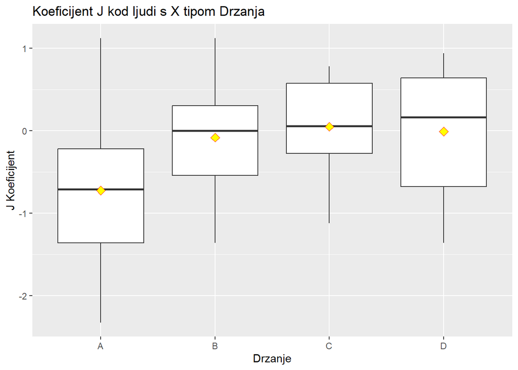

#### Zaključak za Graf 16: Boxplot pokazuje da postoji varijabilnost u J koeficijentu ovisno o držanju, sugerirajući da način na koji osoba održava svoje tijelo može imati implikacije na njezinu sklonost prema planiranju i odlučivanju.

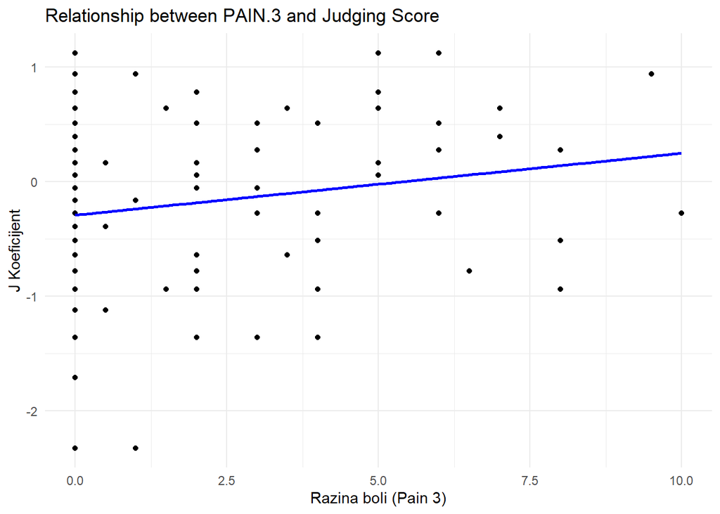

#### Zaključak za Graf 17: Graf ilustrira potencijalnu korelaciju između intenziteta boli u leđima i J koeficijenta. Ovo ukazuje na to da doživljaj boli može utjecati na prosudivacke dijelove ličnosti, kao što su odlučivanje i strukturiranje.

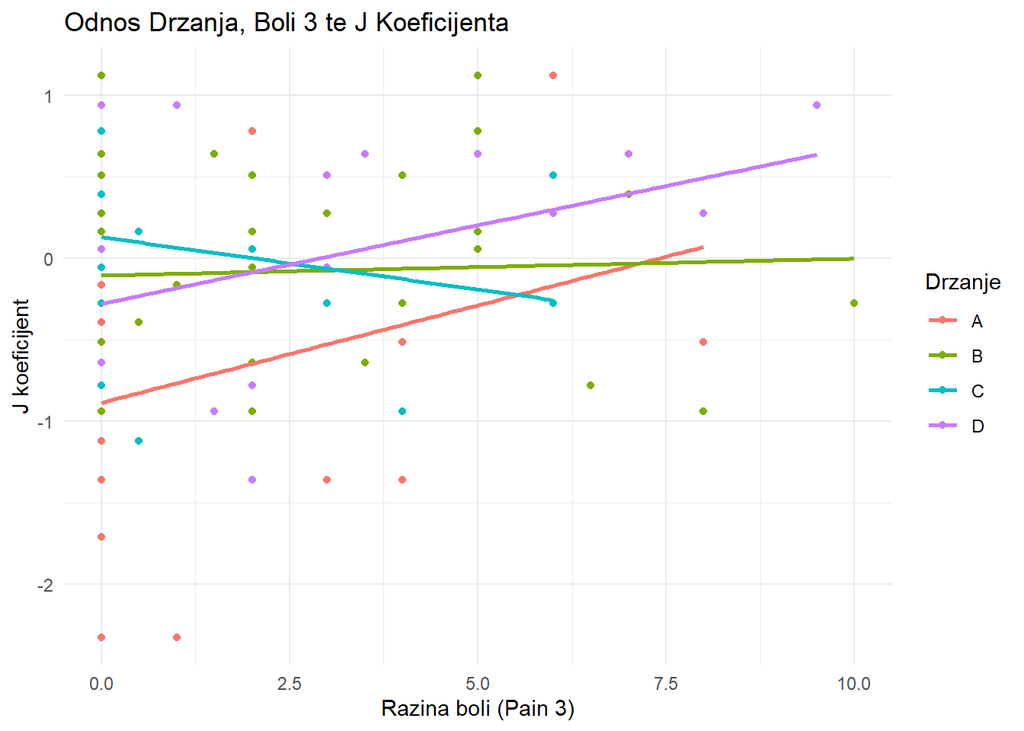

#### Zaključak za Graf 18: Ovaj graf pokazuje interakciju između držanja, intenziteta boli u leđima i J koeficijenta, ističući kako kombinacija ovih faktora može imati složen utjecaj na prosudivacku dimenziju ličnosti.

```
## Netočno pretpostavljeno slovo karakteristike osobnosti:
```

```
## E : 5
## I : 20
## S : 29
## N : 7
## T : 0
## F : 38
## J : 36
## P : 5
```

```
## Vjerojatnost točno predviđenog tipa osobnosti iznosi:  0.6391753
```